# ACTSC 489 Interim Assessment - Frequency Model

# Vehicle make classification

Let’s check if adding Vehicle_make_classification improves our current model. Assessing **significance**, we find that a lot of the bins are not significant (ie the p values are quite large). From a **reasonability** standpoint, it is difficult to justify using this variable for predicting comprehensive claim frequency since it is based on “expected collision loss cost”. For a **parsimony** check, both AIC and BIC increases when Vehicle_make_classification is added, from 15370.02 to 15383.1 for AIC and from 15456.71 to 15729.89 for BIC. However, this large increase in BIC would be expected since when adding Vehicle_make_classification, we add a lot of new parameters which heavily penalises BIC. We also perform an F-test to compare GLM10b and GLM11, we get a p-value of 0.3133, hence there is no evidence that adding Vehicle_make_classification to our model would improve its predictive abilities. From these tests already, we can conclude that we should not include this variable in our model, therefore we did not perform **time consistency** tests for conciseness since we would probably still exclude this variable even if it was consistent across time.

```r
GLM11 <- glm(Comp_claim_count ~ factor(Accident_year) + Marital_status + vehicle_age +
               Annual_distance_cap_35000 + num_yrs_licensed + Vehicle_wheelbase_imputed + Vehicle_make_classification,
                family=quasipoisson(link="log"),
                data = compData,
                offset=log(Comp_earned_count),
                subset=(partition=="Training"),
                na.action="na.pass",
                x = TRUE)
summary(GLM11)
```

```
##
## Call:
## glm(formula = Comp_claim_count ~ factor(Accident_year) + Marital_status +
##     vehicle_age + Annual_distance_cap_35000 + num_yrs_licensed +
##     Vehicle_wheelbase_imputed + Vehicle_make_classification,
##     family = quasipoisson(link = "log"), data = compData, subset = (partition ==
##         "Training"), na.action = "na.pass", offset = log(Comp_earned_count),
##     x = TRUE)
##
## Deviance Residuals:
##     Min       1Q   Median       3Q      Max
## -0.4430  -0.1928  -0.1474  -0.1018   4.0770
##
## Coefficients:
##                                      Estimate Std. Error t value Pr(>|t|)
## (Intercept)                        -4.506e+00  3.417e-01 -13.190  < 2e-16 ***
## factor(Accident_year)2019           3.831e-01  6.977e-02   5.491 4.01e-08 ***
## factor(Accident_year)2020          -1.133e-01  8.211e-02  -1.379 0.167822
## Marital_statusMissing               3.476e-01  2.590e-01   1.342 0.179693
## Marital_statusSingle                1.673e-01  6.534e-02   2.560 0.010478 *
## vehicle_age                        -2.187e-02  8.176e-03  -2.674 0.007487 **
## Annual_distance_cap_35000           2.023e-05  5.735e-06   3.527 0.000420 ***
## num_yrs_licensed                   -7.578e-03  2.265e-03  -3.346 0.000819 ***
## Vehicle_wheelbase_imputed           1.614e-04  6.821e-05   2.366 0.017981 *
## Vehicle_make_classification[ 4, 6)  3.430e-01  2.700e-01   1.270 0.204035
## Vehicle_make_classification[ 6, 7) -1.255e-01  3.815e-01  -0.329 0.742313
## Vehicle_make_classification[ 7, 9)  5.515e-02  2.802e-01   0.197 0.844003
## Vehicle_make_classification[ 9,11)  4.374e-01  2.585e-01   1.692 0.090650 .
## Vehicle_make_classification[11,12)  7.416e-02  3.305e-01   0.224 0.822479
## Vehicle_make_classification[12,14)  2.005e-01  2.666e-01   0.752 0.452088
## Vehicle_make_classification[14,15)  5.639e-01  2.676e-01   2.107 0.035079 *
## Vehicle_make_classification[15,16)  3.495e-01  2.915e-01   1.199 0.230445
## Vehicle_make_classification[16,17)  5.313e-01  2.633e-01   2.018 0.043605 *
## Vehicle_make_classification[17,19)  4.257e-01  2.594e-01   1.641 0.100818
## Vehicle_make_classification[19,20)  7.069e-01  2.846e-01   2.483 0.013014 *
## Vehicle_make_classification[20,21)  5.214e-01  2.885e-01   1.807 0.070761 .
## Vehicle_make_classification[21,23)  4.299e-01  2.586e-01   1.662 0.096441 .
## Vehicle_make_classification[23,24)  6.358e-01  2.776e-01   2.290 0.022032 *
## Vehicle_make_classification[24,25)  6.258e-01  2.821e-01   2.218 0.026563 *
## Vehicle_make_classification[25,26)  4.958e-01  3.001e-01   1.652 0.098518 .
## Vehicle_make_classification[26,27)  5.980e-01  2.899e-01   2.063 0.039158 *
## Vehicle_make_classification[27,29)  5.025e-01  2.678e-01   1.876 0.060654 .
## Vehicle_make_classification[29,30)  6.462e-01  2.655e-01   2.434 0.014947 *
## Vehicle_make_classification[30,31)  4.031e-01  2.908e-01   1.386 0.165636
## Vehicle_make_classification[31,32)  7.216e-01  2.741e-01   2.633 0.008469 **
## Vehicle_make_classification[32,34)  2.045e-01  2.714e-01   0.753 0.451203
## Vehicle_make_classification[34,35)  5.198e-01  3.024e-01   1.719 0.085686 .
## Vehicle_make_classification[35,36)  5.177e-01  2.920e-01   1.773 0.076276 .
## Vehicle_make_classification[36,38)  5.171e-01  2.865e-01   1.805 0.071046 .
## Vehicle_make_classification[38,41)  3.609e-01  3.093e-01   1.167 0.243221
## Vehicle_make_classification[41,99]  5.946e-01  2.847e-01   2.088 0.036774 *
## ---
## Signif. codes:  0 '***' 0.001 '**' 0.01 '*' 0.05 '.' 0.1 ' ' 1
##
## (Dispersion parameter for quasipoisson family taken to be 1.363045)
##
##     Null deviance: 12566  on 112757  degrees of freedom
## Residual deviance: 12311  on 112722  degrees of freedom
## AIC: NA
##
## Number of Fisher Scoring iterations: 7
```

```r
compData %>%
  filter(partition == "Training") %>%
  group_by(Vehicle_make_classification) %>%
  summarise(exposure = sum(Comp_earned_count),
            frequency = sum(Comp_claim_count) / sum(Comp_earned_count))
```

| Vehicle_make_classification | exposure | frequency |
| --- | --- | --- |
| [ 0, 4) | 2595.203 | 0.01310109 |
| [ 4, 6) | 2120.611 | 0.01980561 |
| [ 6, 7) | 1034.333 | 0.01256849 |
| [ 7, 9) | 2294.180 | 0.01612777 |
| [ 9,11) | 2369.336 | 0.02490149 |
| [11,12) | 1180.686 | 0.01863324 |
| [12,14) | 2716.577 | 0.02098229 |
| [14,15) | 2022.685 | 0.03164111 |
| [15,16) | 1533.088 | 0.02543885 |
| [16,17) | 2392.250 | 0.03135124 |

[output cut: 18 more lines]

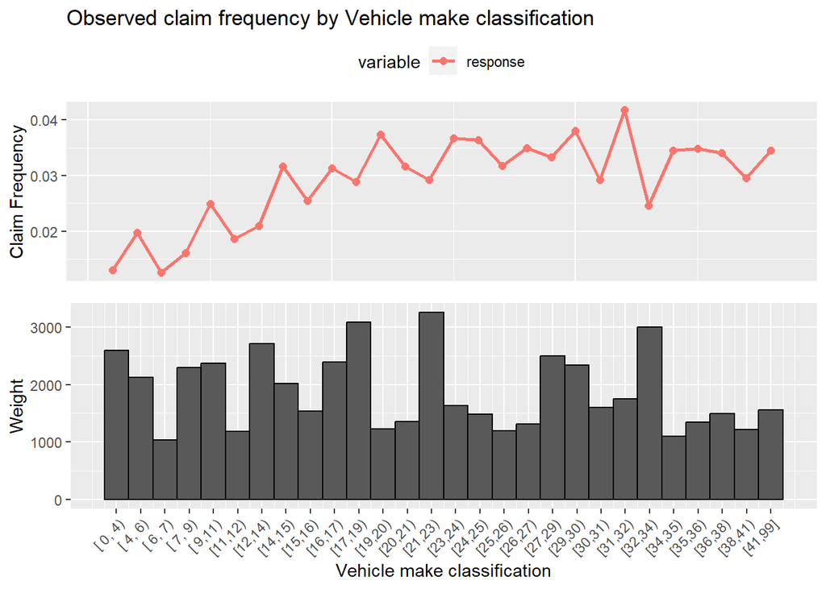

```r
dataToPlot = compData %>%
  filter(partition == "Training") %>%
  mutate(freq = Comp_claim_count / Comp_earned_count)
binnedPlot(response = dataToPlot$freq,
           x = dataToPlot$Vehicle_make_classification,
           weight = dataToPlot$Comp_earned_count,
           type="equal",
           g=12,
           xlab = "Vehicle make classification",
           ylab = "Claim Frequency",
           title = "Observed claim frequency by Vehicle make classification")
```

```r
anova(GLM10b,GLM11, test = "F")
```

|  | Resid. Df | Resid. Dev | Df | Deviance | F | Pr(>F) |
| --- | --- | --- | --- | --- | --- | --- |
| 1 | 112749 | 12351.72 | NA | NA | NA | NA |
| 2 | 112722 | 12310.80 | 27 | 40.91759 | 1.111824 | 0.3133201 |

```r
AIC_BIC(GLM10b)
```

```
## $AIC
## [1] 15370.02
##
## $BIC
## [1] 15456.71
```

```r
AIC_BIC(GLM11)
```

```
## $AIC
## [1] 15383.1
##
## $BIC
## [1] 15729.89
```

# Vehicle horsepower

Next we tried adding Vehicle_horsepower to our model after imputing the missing values with the median from our training data. Hwoever, we find that vehicle_horsepower was not significant with a large p value of 0.77003. Therefore, we decided to exclude it from our model.

# Comp deductible

Next, we try fitting Comp_deductible in our model as a categorical variable taking levels 100, 500 and 1000. We find that the majority of exposures were in the 500 level (see appendix), so we don’t know if that would be a good variable to include due to the low data volume in the other levels. Nonetheless, let’s perform the usual statistical tests.

|  | Coefficients | P-value | 2018 Effect | 2019 Effect | 2020 Effect |
| --- | --- | --- | --- | --- | --- |
| Comp_deductible_ascat1000 | -0.313 | 0.566 | 0.027 | -11.022 | 0.800 |
| Comp_deductible_ascat500 | 0.423 | 0.023 | 0.460 | 0.942 | 0.484 |

# Years since purchased

We create a new variable called yrs_since_purchased which is the number of years since the insured purchased the vehicle. Hence, we calculate the difference between the year of the term effective date and the vehicle purchase year. Again, we impute missing values with the median (3 in this case).

Again we perform our usual tests after fitting the model which we call GLM16. We find that the variable is significant (p value = 0.014285) and the F-test shows a small p value of 0.01103 too. The added variable passes the AIC test but fails the BIC test. Overall, the variable improves the model fit, so we include it for now.

# Years with company

Lastly, we create a new variable, yrs_with_company, which is the number of years someone has been a policyholder with us. However, this variable turned out to not be significant as it had a large p value of 0.118689, so we didn’t include it.

# Final model validation

| GLM10b | GLM16 |
| --- | --- |
| 0.2188594 | 0.2252001 |

Thus, we find although they are quite similar, GLM16 does seem to be a better fit when comparing the Gini coefficients on holdout data. Therefore, we select GLM16 as our final model!

Note that we would need to trend the frequency model’s base rate for the model to be valid in 2021 since our training data only contains information from 2018-2020. That is, we could assign 2020 as accident year to the data we want to predict and the predicted values will have to be trended to 2021 by multiplying the predicted frequencies by a trend factor, which in our case is 1.04 (from our assumptions: loss cost increases by 4% per year).